# Evolutionary epidemiology predicts the emergence of glyphosate resistance in a major agricultural weed - Comont - 2019 - New Phytologist - Wiley Online Library

[New Phytologist](https://nph.onlinelibrary.wiley.com/journal/14698137)

[Volume 223, Issue 3](https://nph.onlinelibrary.wiley.com/toc/14698137/2019/223/3) p. 1584-1594

[figure not shown]

Full paper

# Evolutionary epidemiology predicts the emergence of glyphosate resistance in a major agricultural weed

[David Comont](https://nph.onlinelibrary.wiley.com/action/doSearch?ContribAuthorRaw=Comont%2C+David),

[Helen Hicks](https://nph.onlinelibrary.wiley.com/action/doSearch?ContribAuthorRaw=Hicks%2C+Helen),

[Laura Crook](https://nph.onlinelibrary.wiley.com/action/doSearch?ContribAuthorRaw=Crook%2C+Laura),

[Richard Hull](https://nph.onlinelibrary.wiley.com/action/doSearch?ContribAuthorRaw=Hull%2C+Richard),

[Elise Cocciantelli](https://nph.onlinelibrary.wiley.com/action/doSearch?ContribAuthorRaw=Cocciantelli%2C+Elise),

[Jarrod Hadfield](https://nph.onlinelibrary.wiley.com/action/doSearch?ContribAuthorRaw=Hadfield%2C+Jarrod),

[Dylan Childs](https://nph.onlinelibrary.wiley.com/action/doSearch?ContribAuthorRaw=Childs%2C+Dylan),

[Robert Freckleton](https://nph.onlinelibrary.wiley.com/action/doSearch?ContribAuthorRaw=Freckleton%2C+Robert),

[Paul Neve](https://nph.onlinelibrary.wiley.com/action/doSearch?ContribAuthorRaw=Neve%2C+Paul),

First published: 18 March 2019

https://doi.org/10.1111/nph.15800

See also the Commentary on this article by [Baucom & Busi, **223**: 1056–1058](https://doi.org/10.1111/nph.15959).

## Summary

- The evolution of resistance to herbicides is a striking example of rapid, human-directed adaptation with major consequences for food production. Most studies of herbicide resistance are performed reactively and focus on *post hoc* determination of resistance mechanisms following the evolution of field resistance. If the evolution of resistance can be anticipated, however, pro-active management to slow or prevent resistance traits evolving can be advocated.
- We report a national-scale study that combines population monitoring, glyphosate sensitivity assays, quantitative genetics and epidemiological analyses to pro-actively identify the prerequisites for adaptive evolution (directional selection and heritable genetic variation) to the world's most widely used herbicide (glyphosate) in a major, economically damaging weed species, *Alopecurus myosuroides*.
- Results highlighted pronounced, heritable variability in glyphosate sensitivity amongst UK *A. myosuroides* populations. We demonstrated a direct epidemiological link between historical glyphosate selection and current population-level sensitivity, and show that current field populations respond to further glyphosate selection.
- This study provides a novel, pro-active assessment of adaptive potential for herbicide resistance, and provides compelling evidence of directional selection for glyphosate insensitivity in advance of reports of field resistance. The epidemiological approach developed can provide a basis for further pro-active study of resistance evolution across pesticide resistance disciplines.

## Introduction

The evolution of resistance to pesticides and antibiotics is a signature example of rapid, human-induced adaptation (Palumbi, 2001; Hendry *et al*., 2011; Gould *et al*., 2018) and is a major challenge for applied evolutionary biologists (Carroll *et al*., 2014; Hendry *et al*., 2017). Projected increases in the global human population emphasise the need for a sustainable intensification of agricultural production to ensure food security (Tilman *et al*., 2011). These efforts are hindered by pathogens, insect pests and weedy plants that limit crop yields and increase costs of management (Oerke, 2006). Pesticides have become a mainstay of control strategies for these biotic threats, but exert extreme selective pressures (Rex Consortium, 2013), resulting in the rapid and widespread evolution of resistance (Davies & Davies, 2010; Heckel, 2012; Heap, 2014; Lucas *et al*., 2015). In most cases, once resistance is detectable at significant frequencies within populations, it is difficult to counteract. Consequently pro-active approaches (instigating resistance management before resistance is widespread) are now advocated as they maximise the opportunity to delay the evolution of resistance traits (Mueller *et al*., 2005; Weersink *et al*., 2005). Such approaches can safeguard pesticide use for longer (Beckie, 2011), and provide greater long-term cost-benefits than more reactive measures (Edwards *et al*., 2014). Nevertheless, despite calls for pro-active approaches to resistance management (Tabashnik *et al*., 2014), few studies have sought to pro-actively identify signatures of adaptive evolution, and efforts to manage risks of pesticide resistance have remained largely reactive (Beckie *et al*., 2000).

Competition from weeds is the most significant global crop protection threat (Oerke, 2006), exacerbated by the evolution of herbicide resistance. Prerequisites for the adaptive evolution of herbicide resistance traits include: intense or escalating selection pressure, phenotypic variation for herbicide sensitivity within and between populations, and a heritable basis for that variation. Where historical and contemporary selection pressures can be quantified (via access to herbicide use histories), and where these correlate with heritable variation in herbicide sensitivity, it may be possible to infer patterns of ongoing directional selection for resistance. For polygenic traits, changes in the mean population-level value for herbicide sensitivity may provide a signature of directional selection that anticipates the evolution of field resistance. This dynamic has been described as ‘creeping resistance’ (Gressel, 2009), and where it can be identified pre-emptively, this could provide a means to support and inform proactive resistance management strategies.

To date, resistance to herbicides has evolved in 249 species, worldwide (Heap, 2018). In response to this global epidemic of herbicide resistance, the use of the herbicide glyphosate has increased (Benbrook, 2016). This has been exacerbated in some agroecosystems by the adoption of genetically modified glyphosate-resistant (GR) crops (Green, 2009; James, 2010). Even in cropping systems where GR crops are not grown, glyphosate use has increased (Garthwaite *et al*., 2015). The evolution of resistance to glyphosate was initially considered unlikely (Bradshaw *et al*., 1997). Now, however, resistance has been reported in 41 species (Heap, 2018), including in agroecosystems where GR crops are not grown (Preston *et al*., 2009; Evans *et al*., 2016). The ongoing global evolution of glyphosate resistance provides one of the most striking examples of rapid contemporary evolution in the face of human biotechnological advances.

Black-grass (*Alopecurus myosuroides*) is the most important weed species across Northern and Western Europe (Moss *et al*., 2007; Hicks *et al*., 2018), and its widespread resistance to a broad range of herbicide modes of action (Heap, 2014; Hicks *et al*., 2018) has led to glyphosate becoming one of the last lines of defence in *A. myosuroides* control. Given global precedence for the evolution of glyphosate resistance, there is a need to evaluate the adaptive potential for such a trait within *A. myosuroides* (Davies & Neve, 2017). The scale of the current *A. myosuroides* epidemic, its economic impact and the global importance of glyphosate for crop protection and food security make this an ideal model to assess the utility of a pro-active, epidemiological approach to identify signatures for the evolution of herbicide resistance.

Here, we use a combination of glyphosate sensitivity assays, quantitative genetics and evolutionary epidemiology to examine the potential for evolution of glyphosate resistance in the UK. Using a national-scale survey of 132 *A. myosuroides* populations (Hicks *et al*., 2018) together with 400 pedigreed seed families, we systematically assess national- and field-scale selection pressures, interpopulation variation and heritability of glyphosate sensitivity, experimental responses to glyphosate selection, and correlations between glyphosate sensitivity and a national-scale gradient of selection intensity. We demonstrate significant interpopulation variability in glyphosate sensitivity amongst UK *A. myosuroides* populations. We confirm that this variation is heritable, responds to experimental glyphosate selection and correlates with a selection gradient, demonstrating a response to glyphosate selection in the field. These results provide clear evidence that the prerequisites for glyphosate resistance are evident in black-grass populations and that populations are undergoing selection for resistance in the field, raising significant concerns over current UK glyphosate use patterns. This study provides a novel national-scale, pro-active, epidemiological analysis of resistance risks associated with increasing exposure to the world's most widely used herbicide.

## Materials and Methods

### Black-grass abundance and seed collection

In summer 2014, a series of 138 winter wheat fields spanning 11 counties across England were established as study sites for an audit of black-grass (*Alopecurus myosuroides* Huds.) abundance and herbicide resistance. The chosen fields represented a range of soil types, cropping practices and black-grass abundance, and covered a significant portion of the current UK black-grass geographical range. All fields were surveyed for black-grass abundance using a density-structured approach, dividing each field into contiguous 20 × 20 m quadrats and visually recording black-grass density within each quadrat on a scale of 0–4 (absent to very high) (Hicks *et al*., 2018). Previous studies have shown that this approach can provide a rapid yet reliable measure of weed density for subsequent assessment of weed population dynamics (Queenborough *et al*., 2011). For analysis in this study, a field-scale black-grass density value was used, calculated as the mean density state recorded across all quadrats within a field.

It was possible to collect black-grass seed populations from 132 of the 138 surveyed fields. Seeds were collected from 10 locations in each field. Seed collection sites within a field were selected based on a stratified sampling design to ensure that seeds were collected from a range of locations throughout the field. Seeds were collected by gently shaking mature black-grass seed heads into a paper bag to dislodge mature seeds. At each within-field sampling site, seeds were collected from several plants within a 10 m radius. After collection, seeds were air-dried in the laboratory before being cleaned with an air-column seed cleaner to remove debris and unfilled seeds. For each field (population), a bulk seed sample was created by combining a 50% sample of dried and cleaned seeds from each of the 10 collection sites and thoroughly mixing to provide a single seed population for each field for subsequent experimental work.

### Collection of field management histories

Field management history was collected from a total of 96 of the surveyed fields, including details of the field's crop rotation, cultivation practices and herbicide usage. On average, we obtained 7 yr of management data per field, and this information was used to calculate a range of parameters for analysis (see Supporting Information Table S1). Three measures of glyphosate use were calculated as we wanted to separate glyphosate used primarily for herbicidal control from glyphosate used as a preharvest desiccant outside of the main black-grass growth period. To do this we calculated a mean of the total number of glyphosate applications per year, as well as the mean glyphosate usage during the primary black-grass growing period (herbicidal use, September–May), and mean glyphosate usage during black-grass flowering and seed set (desiccant use, June–August). All 132 black-grass populations have previously been characterised under glasshouse conditions for resistance to the acetolactate synthase (ALS) inhibitors mesosulfuron and iodosulfuron (Atlantis), and the acetyl-CoA carboxylase (ACCase) inhibitors fenoxaprop (Cheetah) and cycloxydim (Laser) (see Hicks *et al*. (2018) for further details). Principal components analyses were performed on the population-level survival of individuals (*n* = 18 per dose) from each previous herbicide screening assay. In all cases, data were scaled and mean-centred before analysis. The first principal component axis (PC1) provided a linear variable that separated populations with contrasting degrees of resistance, and PC1 scores were extracted from each model and the mean calculated per population. These mean PC scores were used as a population-level estimate of resistance to each of these herbicides throughout the current study.

### Temporal change in glyphosate use

A repeated-measures generalised linear mixed model design was used to analyse the overall change in glyphosate use over time. To avoid any potential bias of fields present in one year but not all others, a subset of 67 fields with a complete set of data for 2006–2014 was used for analysis. Annual glyphosate usage per field was assessed as the count of glyphosate applications over September–May and varied from zero to four applications per field per year. Change in glyphosate usage was assessed using a Poisson generalised linear mixed model, with field ID and measurement year included as random terms to account for the repeated-measures nature of the data.

### Glyphosate sensitivity assay

All populations were screened under glasshouse conditions to quantify the extent of variation in glyphosate sensitivity, measured for each population as the glyphosate dose required to kill 50% of individuals (LD<sub>50</sub>). Seeds were germinated in Petri dishes containing two Whatman No. 1 filter papers soaked in 0.02 M KNO<sub>3</sub>. Petri dishes were maintained for 7 d in an incubator (MLR-350; Sanyo, Osaka, Japan) with a 17°C : 11°C temperature cycle and a 14 h : 10 h, light : dark cycle. Six germinated seedlings were transplanted into each 8 cm plastic plant pot, filled with a Kettering loam soil mixed with 2 kg m<sup>−2</sup> osmocote fertiliser. In total 2772 pots (16 632 black-grass plants) were grown, with 21 pots per population providing three replicate pots (*n* = 3) for each of seven herbicide doses. The three replicate pots at each dose were blocked over three glasshouse compartments, with pot position within each compartment determined using a randomised alpha design. Glasshouse compartments were maintained at *c*. 16°C : 14°C for the duration of the experiment (14 March 2016–27 April 2016) and plants were watered daily from above.

The seven glyphosate doses used were control (no herbicide) plus 67.5, 135, 270, 405, 540 and 675 g ha<sup>−1</sup> of glyphosate (current UK glyphosate field rate is 540 g ha<sup>−1</sup>). Plants were sprayed after 3 wk of growth at the three- to four-leaf stage. For spraying, plants were removed from the glasshouse and herbicide was applied using a fixed track-sprayer. The spray nozzle (110015VK; Teejet, Wisbech, UK) was mounted 50 cm above the plants, with boom speed set at 0.33 m s<sup>−1</sup> applying herbicide at a rate of 214 l ha<sup>−1</sup>. Plants were placed back into the glasshouse immediately following spraying. Three weeks after spraying, plants were visually inspected for survival, and any plant with visible new growth was designated as a survivor.

Dose–response analyses were conducted using R (v.3.3.1) and the package drc (Ritz *et al*., 2015). Proportional survival per replicate was calculated from the number of survivors vs total number of plants per pot, and was analysed using a binomial two-parameter regression model, weighted by the total number of plants per pot. Model comparison was performed between two-parameter log logistic, Weibull type-1 and Weibull type-2 fitted curves, as well as unconstrained three- and four-parameter log logistic regression models. Comparison of Akaike's information criterion (AIC) values for the fitted models showed the two-parameter Weibull type-1 to be the optimal model, and this was retained for subsequent analysis. Following curve-fitting, the LD<sub>50</sub> values (the estimated glyphosate doses required to kill 50% of the population) were extracted from the fitted model. The geographical distribution of LD<sub>50</sub> values and percentage survival data were assessed using Mantel tests with the package vegan (Oksanen *et al*., 2017), using the Pearson method with significance estimated following Monte Carlo simulation with 9999 repeats. No evidence was found for spatial autocorrelation of the percentage survival data at either the 540 or the 405 g ha<sup>−1</sup> glyphosate dose (*P* = 0.481 ns, *P* = 0.179 ns), or in the LD<sub>50</sub> values (*P* = 0.371 ns, Table S2).

### LD<sub>50</sub> of glyphosate survivors

Following the glyphosate sensitivity assay, five populations with the greatest total number of surviving plants at the three highest glyphosate doses (405, 540 and 675 g ha<sup>−1</sup>) were identified. Survivors (*n* = 18–22 per population) were individually transplanted into 6-inch pots containing Kettering loam soil, and maintained under ambient outdoor conditions over April–June (Harpenden, UK). All plants recovered above-ground biomass and were moved into 2 × 4 m glasshouses at the onset of floral initiation, allowing plants to cross pollinate and produce seeds. A dose–response assay was carried out under glasshouse conditions to identify if glyphosate sensitivity was altered in the once-selected seed. Seedlings were pre-germinated, grown and sprayed with glyphosate in an identical manner to the previous glyphosate assay. Proportional survival per replicate was calculated from the number of survivors vs total number of plants per pot. Survival data were analysed using a two-parameter regression model with a binomial error term, weighted by the total number of plants per pot, and fitted using the package drc (Ritz *et al*., 2015).

### Quantitative genetic analysis of pedigreed seed families

Nine of the collected *A. myosuroides* populations were used to generate a set of 400 pedigreed seed families with a paternal half-sibling crossing design. At the time of seed collection, 10 sampling locations were identified within each field using a stratified random approach, and five black-grass seed heads were collected at each location. In all cases, seed heads were collected from different individual black-grass plants, with 50 seed heads collected in total from each field. Seeds from each seed head were pre-germinated as previously described, with a single germinated seedling from each head transplanted into individual 6-inch plastic plant pots containing compost. Plants were maintained in a glasshouse for 3 months over September–November, with temperature control set to 16°C : 14°C. Plants were vernalised for 1 month over December by turning off supplemental heating and lighting in the glasshouse. After vernalisation, plants were maintained at 20°C : 15°C with supplemental lighting provided over a 14 : 10 h day to stimulate growth.

Once plants were well established, controlled crossing between paired plants was performed to generate a set of paternal half-sibling seed families for experimentation. In order to do this, one-quarter of the plants from each population were randomly chosen and designated as pollen donors (paternal plants). These plants were split apart using a system of vegetative cloning, creating three genetically identical tillers. Each of the three clones was randomly paired with an uncloned (maternal) individual from the same population, and paired plants were grown together within a glasshouse. At the onset of flowering, paired plants were bagged together using plastic pollination bags, allowing fertilisation of seed heads within each pair, and preventing cross pollination between different pairs. Once seed heads were mature, the pairs were separated, and seeds from each maternal plant were collected by gently shaking heads into a paper bag. As *A. myosuroides* is an obligate outcrossing species, all seeds from the maternal plant were considered to be the result of pollination from the paired paternal plant. In total, 400 pedigreed seed families were produced in this way.

To assess the glyphosate sensitivity of each seed family, seeds were germinated as previously described, with germinated seedlings transplanted into individual 7 cm plastic plant pots. Plants were distributed over three identical, consecutive glasshouse rooms, and maintained at *c*. 16 : 14°C until reaching the three- to four-leaf stage, at which point they were sprayed with glyphosate using the same herbicide track sprayer as previously. In total 8400 black-grass plants were grown, providing seven replicate plants (*n* = 7) for each of three herbicide doses (0, 216 and 378 g ha<sup>−1</sup>). Four weeks after spraying, plants were harvested and above-ground biomass was recorded following oven drying at 80°C for 48 h. Due to constraints on space, all 400 seed families could not be assayed at the same time. Instead, the experiment was performed three times, each time testing a third of the seed families. Approximately equal numbers of families from each of the nine source populations were assessed in each experimental run, and half-sibling families were not split between runs.

The results of glyphosate sensitivity screening for the 400 pedigreed seed families was analysed with an animal model using a Bayesian mixed model approach (Wilson *et al*., 2010), allowing estimation of the additive genetic variance (*V*<sub>A</sub>), covariance (*r*<sub>g</sub>) and narrow sense heritability (*h*<sup>2</sup>) underpinning maintenance of biomass following glyphosate exposure. A three-trait model was assessed, with the response variables being the log-transformed above-ground plant biomass at each of the three glyphosate doses (0, 216 and 378 g ha<sup>−1</sup>). Terms for the experimental run and glasshouse were included as fixed effects, to account for any variance in biomass between glasshouse compartments and over the repeated runs of the experiment. Additional random terms were fitted for maternal effects, and the effect of differences due to the original source population from which the *A. myosuroides* seed was derived. Parameter expanded priors were used, and the residual covariance structure was fixed at zero, to account for each of the focal traits being measured on a different individual plant.

### Field management predictors of glyphosate sensitivity

Field management variables and the principal component scores representing resistance to the previously characterised herbicides ALS and ACCase were evaluated as predictors of glyphosate sensitivity using a linear mixed modelling approach in R (v.3.3.1) with the packager lme4 (Bates *et al*., 2015). All populations with ≥ 4 yr complete herbicide and cultivation records were retained, resulting in 89 populations used for analysis. LD<sub>50</sub> values from the glyphosate sensitivity screening were used as the dependent variable, representing a population-level estimate of glyphosate sensitivity. ‘Farm name’ was included as a random effect to account for other potential unmeasured sources of variability amongst the surveyed farms. An initial set of models were assessed to individually compare the three glyphosate usage measures (total glyphosate use, herbicidal use and desiccant use) as predictors of glyphosate sensitivity (Table S3). Following this, a subsequent larger model was evaluated including the other population, management and resistance measures to identify their relationship with the LD<sub>50</sub> values. Individual terms were added sequentially as fixed effects to the model, with *P*-values calculated for each model term via parametric bootstrapping using the pbkrtest package (Halekoh & Højsgaard, 2014). Marginal and conditional *R*<sup>2</sup> for the fitted model were calculated using the ‘MuMin’ package (Bartoń, 2016). Model residuals showed no significant spatial autocorrelation, assessed using Morans’ I with the package lctools (Kalogirou, 2016; Table S4, Fig. S1), and a backwards step-wise model reduction was performed as a secondary check for the importance of significant model terms (see Table S5).

## Results

### Selection pressure for glyphosate resistance is increasing

Glyphosate usage across the UK has risen considerably, with an approximately eight-fold increase in the area of cereal crops receiving glyphosate treatment over 1990 to 2014 (Garthwaite *et al*., 2015) (Fig. 1a). To establish if glyphosate usage has changed over time at our survey locations, a set of 67 fields with a full herbicide application history for the period 2006–2014 were assessed for temporal trends in glyphosate usage. A significant increase in glyphosate use over this time was observed (Fig. 1b), confirming that selection pressure for a GR trait is probably increasing within UK agriculture. UK farmers are increasingly reliant on glyphosate for weed control, highlighting the potential for significant agronomic, economic and environmental consequences if glyphosate resistance were to evolve.

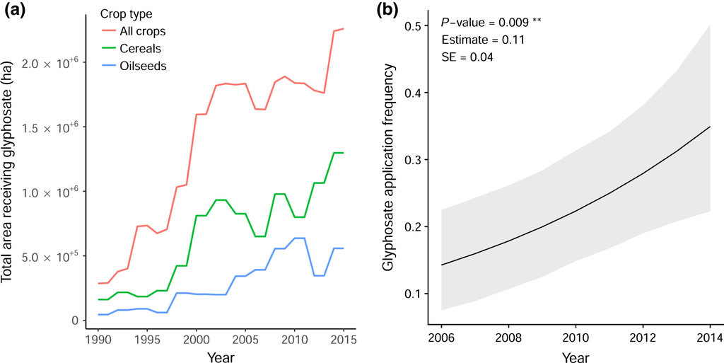

**Figure 1**

Historical pattern of glyphosate usage within Great Britain. (a) Total area receiving glyphosate treatment. Data were collated from the FERA pesticide usage survey (Garthwaite *et al*., 2015). (b) Estimated change in annual frequency of glyphosate applications ± 95% confidence bounds (shaded region) following generalised linear mixed-model analysis of glyphosate usage histories from 67 fields with a complete set of data spanning 9 yr from 2006 to 2014. *P*-value and estimated slope of the relationship are shown (*Z*-statistic = 2.613 with 598 residual degrees of freedom). Significance is denoted by asterisks at: **, *P* ≤ 0.01.

### *A. myosuroides* populations exhibit considerable variation in glyphosate sensitivity

We found evidence for considerable interpopulation variability in sensitivity to glyphosate (Figs 2, 3). The recommended field application rate for glyphosate in the UK (540 g ha<sup>−1</sup>) resulted in a mean population-level mortality of 95.4% (± 0.6 SE), indicating the potential for some individuals to survive in a field situation. Notably, the percentage mortality at a 405 g ha<sup>−1</sup> dose (×0.75 field rate) varied from 94% to 15% amongst populations (Fig. 2). Interpopulation variation in glyphosate sensitivity is clearly evident from an analysis of LD<sub>50</sub> values (dose resulting in 50% mortality), which ranged from 230 to 470 g ha<sup>−1</sup> (Fig. 3). These levels of variation suggest that glyphosate may not currently provide complete control of treated plants in field situations. If variation in sensitivity is a heritable trait, these observations suggest that there is potential for ongoing adaptation to glyphosate in UK blackgrass populations.

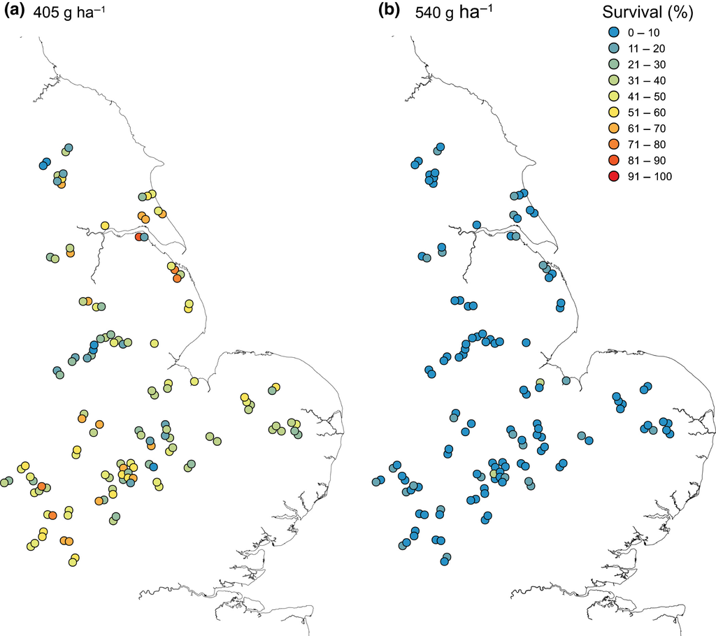

**Figure 2**

Location of the *Alopecurus myosuroides* populations used throughout the current study. Colours denote percentage survival of each population following a glasshouse whole-plant assay at (a) 405 g ha<sup>−1</sup> glyphosate treatment (×0.75 field rate) and (b) 540 g ha<sup>−1</sup> glyphosate treatment (field rate). Survival was assessed for 18 plants per population per dose, 3 wk after herbicide application. See also Supporting Information Table S2 for details on spatial autocorrelation analysis.

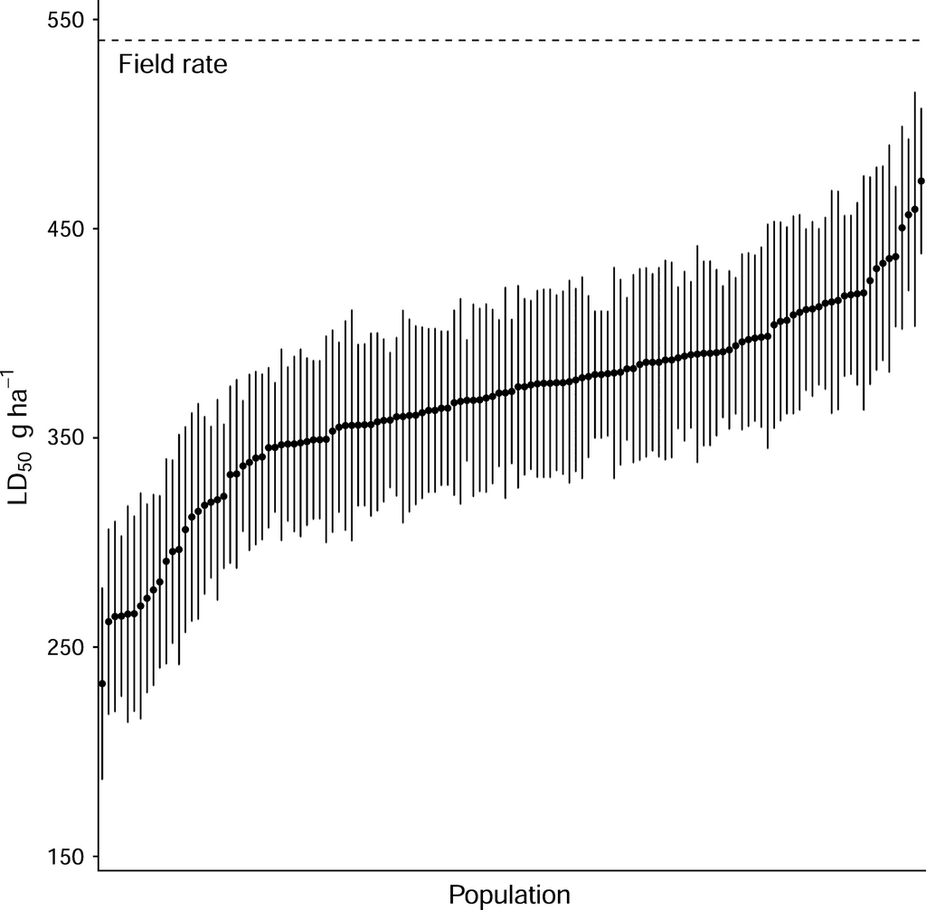

**Figure 3**

Glyphosate LD<sub>50</sub> values (± 95% CI) of the field-collected *Alopecurus myosuroides* populations, calculated from a fitted dose–response model of survival data. Data were derived from a whole-plant dose–response assay under glasshouse conditions, using seedlings grown from 132 field collected seed populations. The *y*-axis shows the glyphosate dose required to kill 50% of individuals in each population (LD<sub>50</sub>), with populations along the *x*-axis sorted from the most sensitive (left) to least sensitive to glyphosate (right).

### Reduced sensitivity to glyphosate is heritable

We found that variation in plant biomass following glyphosate application was heritable (Fig. 4). The log-transformed biomass of unsprayed plants had a narrow-sense heritability (*h*<sup>2</sup>) of 0.27 (95% credible interval from 0.15 to 0.45), indicating that variability in early plant establishment and growth has a weak heritable basis. At the higher glyphosate dose (378 g ha<sup>−1</sup>), heritability was similar at 0.28 (95% credible interval from 0.17 to 0.43) (Fig. 4a). However, no evidence was found for a genetic correlation between the biomass of treated and untreated plants (posterior mean of 0.035, 95% credible interval from −0.48 to 0.37) (Fig. 4b), indicating that higher plant biomass following glyphosate treatment was not simply a function of intrinsic differences in plant growth rates. In a further experiment, a significant response to glyphosate selection was observed amongst a subset of populations from the initial glyphosate sensitivity assay. Dose–response analysis of progeny from survivors of glyphosate application indicates that the LD<sub>50</sub> values of the once-selected population is significantly greater than for the baseline population (Fig. 4c), with several survivors at the glyphosate field rate (540 g ha<sup>−1</sup>). These results clearly indicate that glyphosate sensitivity is heritable, and given the increasing frequency of glyphosate usage observed (Fig. 1), raises the possibility that UK black-grass populations are experiencing ongoing and escalating selection for reduced glyphosate sensitivity.

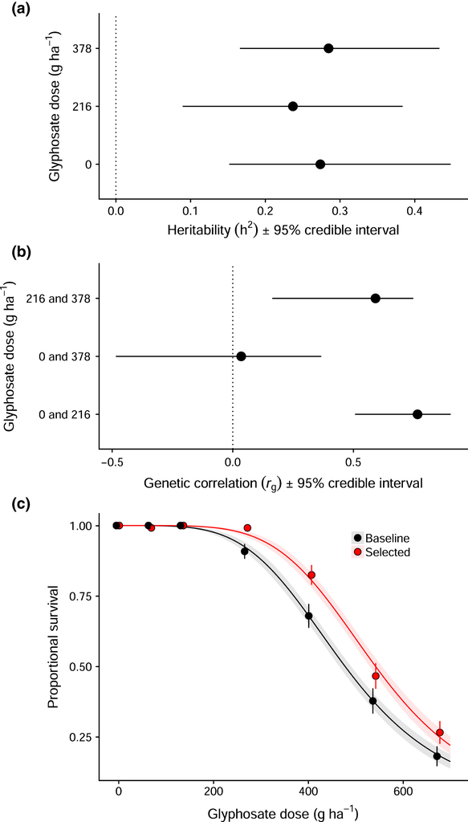

**Figure 4**

### Glyphosate resistance is under selection in the field

For populations in which historical glyphosate selection pressure could be established from field management histories (*n* = 89), selection intensity was found to be a significant predictor of the glyphosate LD<sub>50</sub> (Table 1). The relationship was positive, indicating that increased selection pressure is driving an evolutionary response for reduced glyphosate sensitivity. The nonherbicidal use of glyphosate as a preharvest desiccant was independently assessed as a predictor of the LD<sub>50</sub>, but no significant relationship was found (see Table S3). The only other significant predictor of glyphosate sensitivity was black-grass emergence (Table 1). This variable estimates the mean proportion of the *A. myosuroides* population that was exposed to glyphosate treatment. The relationship is positive, suggesting that selection pressure is greater when a higher proportion of the population is exposed to glyphosate. Black-grass population density at the field collection site was not significantly related to the glyphosate LD<sub>50</sub> however, suggesting that population size was not a major driver of higher glyphosate LD<sub>50</sub> values or vice versa. Use-histories for other herbicide modes of action, and the previously characterised population-level degree of resistance to those modes of action, were also not predictive of the glyphosate LD<sub>50</sub>. These results confirm an epidemiological link between glyphosate usage and reduced glyphosate sensitivity, providing compelling evidence that this trait is undergoing selection in the field.

Table 1. Results of a mixed-model analysis for the effect of field management histories and phenotypic resistance to other herbicide modes of action on glyphosate sensitivity (LD<sub>50</sub> values) of UK *Alopecurus myosuroides* populations

| Fixed effects | df | Estimate | SE | Sum of squares | *P*-value |
| --- | --- | --- | --- | --- | --- |
| Population size and cultivation |  |  |  |  |  |
| Black-grass density | 1 | −0.007 | 0.115 | 0.793 | 0.217 ns |
| Proportion autumn sown | 1 | 0.408 | 0.134 | 0.417 | 0.517 ns |
| Black-grass emergence | 1 | 0.270 | 0.143 | 3.027 | 0.026* |
| Cultivation score | 1 | 0.150 | 0.118 | 0.133 | 0.661 ns |
| Herbicide usage |  |  |  |  |  |
| Glyphosate (Sep–May) | 1 | 0.452 | 0.156 | 3.407 | 0.008** |
| HRAC turnover | 1 | 0.164 | 0.138 | 1.129 | 0.142 ns |
| HRAC diversity | 1 | −0.126 | 0.152 | 0.379 | 0.447 ns |
| HRAC mixing | 1 | −0.092 | 0.121 | 0.060 | 0.763 ns |
| Herbicide resistance |  |  |  |  |  |
| Atl survival PC | 1 | 0.277 | 0.149 | 1.649 | 0.081 ns |
| Cyc survival PC | 1 | −0.330 | 0.157 | 1.612 | 0.096 ns |
| Fen survival PC | 1 | 0.170 | 0.129 | 0.865 | 0.238 ns |
| *R*<sup>2</sup> marginal: 0.240 | *R*<sup>2</sup> conditional: 0.565 |  |  |  |  |

- Variables representing historical field cultivation and herbicide use, and principal components scores representing phenotypic resistance to other herbicides were included as fixed effects (see Supporting Information Table S1 for definitions), while farm was fitted as a random effect to account for nonindependence. Individual terms were added sequentially, and the significance of each term was calculated by comparison to the previous model using parametric bootstrapping.
- Asterisks denote significance at: *, *P* ≤ 0.05; **, *P* ≤ 0.01; ns, non-significant.

## Discussion

Previous epidemiological assessment of UK populations of *Alopecurus myosuroides* (black-grass) has revealed widespread resistance to post-emergence herbicides, driven by herbicide exposure (Hicks *et al*., 2018). In the current study we have extended this epidemiological approach, using a combination of glyphosate sensitivity assays, quantitative genetics, systematic population monitoring and the dissection of selection histories to provide a pre-emptive assessment of the evolution toward a glyphosate resistance trait. We have demonstrated that selection pressure for glyphosate resistance is increasing amongst UK populations of black-grass. We show that standing phenotypic variation in glyphosate sensitivity both within and between black-grass populations has a heritable basis that responds to selection, and that population-level variation in glyphosate sensitivity correlates with a selection gradient, revealing the evolutionary potential for a glyphosate resistance trait within this species.

In the fields of agriculture, medicine and conservation biology, it is now widely recognised that the evolution of organisms in the face of human activity can occur rapidly, on contemporary timescales (Hendry *et al*., 2011, 2017). Eco-evolutionary approaches are now being adopted to study adaptation to anthropogenic selection from a conservation perspective (Cotto *et al*., 2017), for example to identify key components of climatic change associated with changes in biodiversity (Greenville *et al*., 2018), and to highlight species at risk (Jordan *et al*., 2017). Insight from such studies can be used to proactively predict evolutionary responses to future anthropogenic climate change (Ikeda *et al*., 2017; Inoue & Berg, 2017), highlighting organisms and habitats for more concerted conservation. Whilst rapid evolution is often desirable for efforts to conserve species and ecosystems in the face of environmental change, in agriculture and medicine this process is epitomised by the evolution of resistance to pesticides and antimicrobials (Rex Consortium, 2013), threatening efforts to produce food and maintain healthy populations (Carroll *et al*., 2011). While the evolution of resistance has traditionally been studied reactively (Beckie *et al*., 2000), there has been a growing realisation of the need to understand the key evolutionary drivers of resistance, and to act pro-actively to minimise the evolution of resistance to new and future chemistry (Holmes *et al*., 2016; Gould *et al*., 2018).

Glyphosate, a broad-spectrum nonselective herbicide first introduced in 1974, is now the world's most widely used herbicide (Benbrook, 2016). While glyphosate resistance was originally considered unlikely, it has now been shown to evolve independently in a wide range of species across many different agricultural systems (Preston *et al*., 2009; Evans *et al*., 2016). First reported in populations of *Lolium rigidum* from Australia (Powles *et al*., 1998), evolved glyphosate resistance has now been confirmed in 41 species globally (Heap, 2018), with many recent cases reported following the adoption of genetically modified GR crops (Powles, 2008). Given the precedent for such widespread response to glyphosate selection, resistance has now been predicted to occur wherever glyphosate usage has increased, and where resistance to other available control options has evolved (Preston *et al*., 2009), with highly fecund, outcrossing species such as *A. myosuroides* expected to have a greater risk of glyphosate resistance evolution in these situations (Neve, 2008). In the current study, glyphosate use was shown to have risen significantly, with national-scale data reflecting an eight-fold increase in glyphosate usage (FERA, 2017). Given this, and the widespread resistance of *A. myosuroides* to other control options (Hicks *et al*., 2018), we can infer that the selective pressure for glyphosate resistance in UK *A. myosuroides* populations is increasing, highlighting concerns over current glyphosate use patterns.

Although herbicide resistance has often been regarded as a binary, single gene trait inherited in Mendelian fashion, there is a growing recognition that many resistance mechanisms are inherited quantitatively (Gressel, 2009; Délye *et al*., 2013; Manalil, 2015). Such quantitatively inherited resistance is now confirmed across multiple taxa, conveying resistance to herbicides (Délye *et al*., 2013), fungicides (Zhan *et al*., 2006) and antibiotics (Mwangi *et al*., 2007). Whilst glyphosate resistance is sometimes attributed to single major-gene mechanisms (Sammons & Gaines, 2014), there is now evidence that it can also be inherited as a quantitative trait (Busi & Powles, 2009; Chandi *et al*., 2012; Mohseni-Moghadam *et al*., 2013). For example, EPSPS gene amplification has been shown to convey glyphosate resistance, with the extent of resistance positively correlated with EPSPS gene copy number (Gaines *et al*., 2010). Vacuolar sequestration and reduced translocation are the predominant resistance mechanisms in many weed species, and can convey variable and population-specific levels of resistance (Dominguez-Valenzuela *et al*., 2017; Fernández-Moreno *et al*., 2017). In *Conyza canadensis*, Tani *et al*. (2015) found that resistance involved synchronised upregulated expression of multiple ABC transporter genes, while Maroli *et al*. (2015) found a role for reactive oxygen species scavenging potential and upregulation of the phenylpropanoid pathway in glyphosate resistance in *Amaranthus palmeri*. These mechanisms can give rise to quantitative patterns of resistance, potentially under polygenic control, which may evolve via a sequential accumulation of alleles conveying minor effects; this is also called ‘creeping resistance’ (Gressel, 2002).

The pronounced, and heritable, variation in sensitivity to glyphosate demonstrated by the current study provides compelling evidence that the adaptive potential for a glyphosate resistance trait is present amongst UK *A. myosuroides* populations. Although mean mortality at field application rates was high (95.4%, ± 0.6 SE) survivors at this dose were observed in several populations, demonstrating the potential for individuals to survive glyphosate application within agricultural fields, particularly where suboptimal spraying conditions lead to lowered effective doses. Davies & Neve (2017) found comparable variation in glyphosate sensitivity between UK *A. myosuroides* populations, and demonstrated that two generations of experimental glyphosate selection were enough to significantly increase glyphosate LD<sub>50</sub> values. Similar heritable variation in glyphosate sensitivity in the comparable grass weed *Lolium rigidum* has been shown to facilitate the evolution of a glyphosate resistance trait (Busi & Powles, 2009). Whilst heritabilites were lower than those reported for some adaptive traits in other grasses (Studer *et al*., 2008; Majidi *et al*., 2009), quantitative genetic analysis confirms that there is an additive genetic basis to glyphosate sensitivity, with population-level resistance shown to increase following just one generation of selection. Given the existence of this heritable, additive genetic variance, standard quantitative genetics models would predict that ongoing selection with glyphosate will provide continued directional selection for reduced glyphosate sensitivity, ultimately resulting in increasing survival frequencies at realistic field application rates. The observed sustained increase in national glyphosate usage, and the correlation between historical selection and population-level glyphosate sensitivity, suggest that this directional selection is already occurring in the field.

It has been argued that a more integrated understanding of the processes contributing to the evolution of herbicide resistance at the population and ecosystem level is needed (Neve *et al*., 2009; Busi *et al*., 2013), and epidemiological approaches (studying the origin, distribution and transmission of detrimental organisms or alleles) have been suggested as an important tool in generating this understanding (Gressel, 2002). Epidemiological approaches have proven valuable in this capacity, for example elucidating the dynamics of plant disease epidemics (Gigot *et al*., 2017; Ojiambo *et al*., 2017), understanding the evolution of azole resistance in *Candida* and *Aspergillus* species (Gonçalves *et al*., 2016), and predicting the distribution of resistant weeds in Italian rice cropping regions (Mascanzoni *et al*., 2018), yet such studies remain rare. In the current study, epidemiological analysis using historical field management data provides clear evidence of glyphosate usage causing selection for reduced glyphosate sensitivity in the field. Previous studies have similarly found evidence for herbicide intensity driving evolved herbicide resistance in *A. myosuroides* (Hicks *et al*., 2018), and for associations between glyphosate use and glyphosate resistance in *Amaranthus tuberculatus* (Evans *et al*., 2016). However, these studies were reactive, using resistance epidemiology after widespread control failure. The low observed survival at the field-rate glyphosate dose, and the lack of a significant association between LD<sub>50</sub> and *A. myosuroides* abundance in the current study suggests that current variation in glyphosate sensitivity is not yet compromising control of these populations under field conditions. As a result, none of the tested populations would yet be considered to possess an evolved glyphosate resistance trait, providing an opportunity for pro-active intervention to limit further selection for resistance. The current study reaffirms the utility of an epidemiological approach and crucially, demonstrates that such approaches can provide valuable information on the risk and key evolutionary drivers of a pesticide resistance trait pro-actively, before any confirmed cases of resistance are observed.

It is now widely recognised that instigating approaches for resistance management pro-actively can maximise the efficacy of any intervention, and potentially delay the evolution of resistance (Mueller *et al*., 2005; Weersink *et al*., 2005). Farmers are increasingly receptive to proactive resistance management if it can safeguard herbicide use for longer (Beckie, 2011), and because higher short-term costs (Weersink *et al*., 2005) are often compensated for by higher yields and greater profitability in the longer term (Edwards *et al*., 2014). As a result, approaches such as those in the current study which pre-empt evolution, and identify specific management factors to target for pro-active management, will become increasingly important for managing contemporary evolution of resistance to anthropogenic selection. Pro-active surveillance to detect early signatures of selection for resistance is already being adopted for management of antimicrobial resistance (Hawser, 2012; Morrissey *et al*., 2013). For weeds, studies with a greater emphasis on quantifying heritable variation in herbicide sensitivity before resistance is reported could form the basis for pro-active surveillance programmes. When coupled with experimental evolutionary and quantitative genetics studies to assess adaptive potential (Davies & Neve, 2017), systematic monitoring for herbicide escapes in-field, and potential development of simple molecular markers for resistance (Tétard-Jones *et al*., 2018), growers and researchers would be better equipped to identify and pro-actively manage resistance risks. In the current *A. myosuroides* example, the evidence clearly shows that it is the intensity of glyphosate usage which is providing selection for reduced glyphosate sensitivity. Introducing measures now to curb the continued increase in glyphosate usage will provide the best opportunity to delay or prevent a glyphosate resistance trait evolving in this species.

## Acknowledgements

This work was conducted with funding from the Biotechnology and Biosciences Research Council (BBSRC; BB/L001489/1) and the Agriculture and Horticulture Development Board (AHDB). EC was supported by a studentship from AgroParisTech, France. We are grateful to all of the individual farmers and growers who contributed management data and allowed access to sites for black-grass monitoring and seed collection. The dose–response study was conducted in the glasshouse facilities at Rothamsted Research and we wish to thank everyone that was involved with growth and maintenance of the plants, in particular Imogen Durenkamp and Helen Metcalfe for helping to sow and harvest plants.

## Author contributions

DC and PN conceived and designed the study. DC and HH led the field monitoring and collection of seed populations and farm management data. DC, LC, RH and EC performed glasshouse experiments. DC analysed data with statistical advice provided by RF, D. Childs., JH and HH. Research funding for this project was awarded to PN, RF and D. Childs. The paper was written by DC and PN, with contributions from all authors.

[figure not shown]

[figure not shown]

[figure not shown]